# The Influnce of Plant Partner Variability on Population Dynamics and Network Roles in Willamette Valley Prairies

Jacob Swanson

2025-11-11

### I. Introduction

Species-level traits are a central focus in ecology because they influence species fitness (Bergamo, Traveset, and Lázaro 2021), regulate population dynamics (Herrera 2005), and even shape evolutionary trajectories (Cosmo et al. 2023). These traits structure interactions within plant–pollinator networks, which is important because mutualistic networks provide essential ecosystem services in both natural and agricultural systems (Waser 2006). Network theory predicts that pairwise interactions change through space. Highly dynamic pairwise interactions complicates our ability to generalize plant species’ network roles across a landscape. Examining partner variability as a plat trait, and how this trait influences network niche through space can help inform conservation planning of rare, cultural, and restoration valuable plants.

Mutualistic networks consist of two interacting communities called nodes that are connected by links. Using a bipartite approach, we can map species interactions and identify species roles within a network. Well-characterized pairwise interactions change spatially and temporally (L. W. Aarssen 1989; L. Aarssen 1992; Bengtsson, Fagerström, and Rydin 1994; Carstensen et al. 2014). This variation is driven by temporal variation in species composition and phenology (Alarcón, Waser, and Ollerton 2008; Olesen et al. 2008) and interaction re-wiring due to disturbance (Ponisio 2020) or resource availability (Valdovinos et al. 2016).

An important aspect of species diversity is beta diversity–the spatial turnover of species interactions (Carstensen et al. 2014). The dissimilarity in beta-diversity of populations in a region is low if populations are interacting with the same species compositions and high when interacting with unique compositions (Ponisio 2020). Plant species exhibit substantial variability in their interaction partners among conspecific individuals within a population (Gómez, Perfectti, and Jordano 2011), across populations (González, Murúa, and Pérez 2015), and among communities (Herrera 2005). Flexible pairwise interactions likely contribute to a plant species ability to shift between network niches when community composition changes. Thus, it is valuable to examine whether species that are flexible in their interaction partners can occupy different as community composition changes through space.

This study focuses on prairies in the Willamette Valley ecoregion in Oregon. Over the past 175 years native prairie ecosystems in the Pacific Northwest have suffered a drastic decline, with approximately 90-98% lost throughout the region (Sinclair et al. 2006; Altman 2011). Advancing our understanding of interaction-based ecosystem services by treating partner variability as a trait and evaluating its impacts on population dynamics and network niches is essential for informing conservation planning of these imperiled ecosystems. Yet, studies that link partner variability and network niche remains scarce (see Ponisio (2020)). Here, I assess plant partner variability as a trait, and how this trait may predict population dynamics and network niches.

Across populations plants show substantial variation in their interaction partners. This is likely explained by shifting compositions of available interaction partners as community compositions change with geographic distance (Carstensen et al. 2014). As plants become more flexible in their interaction partners, their interannual population dynamics are likely to be less variable because they can more reliably obtain necessary pollination services. Moreover, the network roles they occupy may shift accordingly. This flexible behavior has been observed in plant populations of *L. latifolia* (Herrera 2005), and pollinator populations (Ponisio 2020; Gaiarsa, Kremen, and Ponisio 2021). These insights have motivated three hypothesis: (1) As beta-diversity increases, the role of a plant within the network will shift. (2) As plants become more flexible in their interaction partners they will show more variation in their network niche (3) Plants that are more flexible in their interaction partners will have a negative relationship with changes in floral abundance among years.

### II. Data

Data was provided by our collaborator Susan Waters with Quamash EcoResearch. This dataset included plant-pollinator interactions across 10 sites within the Willamette Valley Ecoregion in Oregon from 2019-2022. The data was collected using standardized timed hand-netting survey methods where bees are collected when actively engaging in pollination. The interacting plant species partners were recorded in all observations and identified to species. Bee species were identified as morphospecies or species when feasible. Site and date (survey round) were recorded for all observations. Using the raw data I created a vegetation dataset that included all plant species sampled and their abundances for each survey round within a site and year, a network dataset that included all plant pollinator interactions, and a spatial dataset with the latitude and longitude converted to a vector (see below). The preparation of datasets and the development of the analytical approach was based on the steps used in Ponisio (2020). The code was sourced from github and modified to meet the analytical destination in the present study.

### III. Data Wrangling

All data preperation was done in 0DataPrep.R

```r
setwd('C:/pisgah-prairie/data')
#loads packages
source('../analysis/src/packages.R')
```

*Specimen Data*

```r
setwd('C:/pisgah-prairie/data')
source('../data/src/misc.R')
source('../data/src/prepNets.R')

##******************************************************
## Clean specimen data
##******************************************************
spec <- read.csv(
  "raw/susans_data_normalized.csv",
  colClasses = "character")

dim(spec) #14211 x 11
```

```
## [1] 14211    19
```

```r
#changes date to single format, date class, and create year column
spec$Date <- lubridate::parse_date_time(
  spec$Date,
  orders = c("d-b-y", "Ymd")
)

spec$Date <- as.Date(spec$Date)

class(spec$Date)
```

```
## [1] "Date"
```

```r
spec <- spec %>%
  dplyr::mutate(
    Year = year(Date))

#drop empty cells and NA
spec <-  spec[spec$Genus != '',]
spec <-  spec[spec$Species != '',]
spec <-  spec[spec$PlantGenusSpecies != '',]
spec <-  spec[!is.na(spec$Genus),]
spec <-  spec[!is.na(spec$Species),]
spec <-  spec[!is.na(spec$PlantGenusSpecies),]

# Count NAs in each column
sum(is.na(spec$Genus))
```

```
## [1] 0
```

```r
sum(is.na(spec$Species))
```

```
## [1] 0
```

```r
sum(is.na(spec$PlantGenusSpecies))
```

```
## [1] 0
```

```r
#Create genus species column
spec$GenusSpecies <- paste(spec$Genus,
                           spec$Species)

#interactions
spec$Int <- paste(spec$GenusSpecies,
                  spec$PlantGenusSpecies)

dim(spec) #5147   22
```

```
## [1] 5152   22
```

```r
## drop non-bees
unique(spec$Family)
```

```
##  [1] "Andrenidae"    "Apidae"        "Bombyliidae"   "Conopidae"
##  [5] "Halictidae"    "Chrysomelidae" "Coccinellidae" "Rhagionidae"
##  [9] "Syrphidae"     "Vespidae"      "Megachilidae"  "Cleridae"
## [13] "Colletidae"    "\tHalictidae"  "Pompilidae"    "Crabronidae"
## [17] "Cerambycidae"  "Attelabidae"   ""              "Pollenidae"
## [21] "Tachinidae"    "Meloidae"      "Calliphoridae" "\tSyrphidae"
## [25] "Chrysididae"   "Elateridae"    "Sphecidae"
```

```r
bee.fams <- c("Halictidae", "Andrenidae", "Apidae", "Megachilidae",
              "Colletidae", "Bombyliidae")

spec <- spec[spec$Family %in% bee.fams,]

#summary
print(paste("Bee species", length(unique(spec$GenusSpecies))))
```

```
## [1] "Bee species 123"
```

```r
print(paste("Plant species", length(unique(spec$PlantGenusSpecies))))
```

```
## [1] "Plant species 89"
```

```r
print(paste("Bee genera", length(unique(spec$Genus))))
```

```
## [1] "Bee genera 23"
```

```r
print(paste("Interactions", length(unique(spec$Int))))
```

```
## [1] "Interactions 623"
```

```r
print(paste("Specimens", nrow(spec)))
```

```
## [1] "Specimens 2885"
```

```r
print(length(unique(spec$Site)))
```

```
## [1] 10
```

```r
dim(spec)
```

```
## [1] 2885   22
```

*Network Data*

To prepare the network matrices for network analysis, I formatted the specimen dataset into a list of interaction matrices for each survey round at each site within a year.

```r
##******************************************************
## networks
##******************************************************
spec <- spec[!spec$PlantGenusSpecies == "",]

nets <- break.net(spec)
nets <- unlist(nets, recursive=FALSE)
```

*Vegetation Data*

To create a vegetation dataset with floral counts, I standardized the plant naming conventions using GBIF. I renamed the columns to match the specimen dataset and changed the date to a single format and created a year column. I then dropped all empty cells and NA values in the plant genus and species columns.

```r
##******************************************************
## clean veg data
##******************************************************

##Create veg dataset
raw <- read_csv('C:/pisgah-prairie/data/raw/PPP_PollObs_OR_upto2022_NEW_IDs_20240108 (2).csv')
norm1 <- read_csv('C:/pisgah-prairie/data/raw/normalized1.csv')
norm2 <- read_csv("C:/pisgah-prairie/data/raw/normalized2.csv")
norm3 <- read_csv('C:/pisgah-prairie/data/raw/normalized3.csv')

norm <- rbind(norm1, norm2, norm3)

raw <- raw %>%
  select(State, County, Latitude, Longitude, site, date, time, temp, hum, wind, plants_per_m2, patch_size)

veg <- cbind(norm, raw)

#select and rename columns
veg <- veg %>%
  select(-occurrenceId, -acceptedUsageKey, -usageKey, -authorship, -canonicalName, -verbatimScientificName, -matchType, -confidence, -key) %>%
  rename(Date = date, Site = site, PlantGenusSpecies = species, Genus = genus, Family = family, Kingdom = kingdom, Phylum = phylum, Class = class, Order = order, FlowerNum = plants_per_m2)

#changes date to single format, date class, and create year column
veg$Date <- lubridate::parse_date_time(
  veg$Date,
  orders = c("d-b-y", "Ymd")
)

spec$Date <- as.Date(spec$Date)

class(spec$Date)
```

```
## [1] "Date"
```

```r
#create year column
spec <- spec %>%
  dplyr::mutate(
    Year = year(Date))

#drop empty cells and NA
veg <-  veg[veg$Genus != '',]
veg <-  veg[veg$PlantGenusSpecies != '',]
veg <-  veg[!is.na(veg$Genus),]
veg <-  veg[!is.na(veg$PlantGenusSpecies),]

## correct date format
veg$Date <- as.Date(veg$Date, format='%m/%d/%y')
veg$Year <- format(veg$Date, format='%Y')
veg$doy <- as.numeric(strftime(veg$Date, format='%j'))

#identify species occurrences and convert to binary
veg$FlowerNum[is.na(veg$FlowerNum)] <- 0
veg$Occ <- veg$FlowerNum
veg$Occ[veg$Occ > 0] <- 1
```

### IV. Observed & Null Communities

```r
setwd('C:/pisgah-prairie/analysis')
this.script <- "nulls"
source('src/misc.R')
source('src/calcPca.R')
source('src/calcSpec.R')
source('src/commPrep.R')
source('src/vaznull2.R')

load('../data/specimens/spec1.Rdata')
load('../data/specimens/nets1.Rdata')
save.path <- 'saved'

save.dir.comm <- "saved/communities"
save.dir.nulls <- "saved/nulls"

type <- "plant"
nnull <- 9
species.type="PlantGenusSpecies"
species.type.int="GenusSpecies"

sites <- unique(spec$Site)
years <- unique(spec$Year)

## ************************************************************
## year by species matrices plants
## ************************************************************
comms <- lapply(years, calcSiteBeta,
                species.type=species.type,
                spec=spec,
                species.type.int=species.type.int)

comm <- makePretty(comms, spec)

## ************************************************************
## alpha div nulls
## ************************************************************
nulls <- rapply(comm$comm, vaznull.2, N=nnull, how="replace")

## ************************************************************
## occurrence nulls
## ************************************************************
occ.null <- function(web){
    simulate(vegan::nullmodel(web, method="quasiswap"),1)[,,1]
}

rep.occ.null <- function(web, N){
    replicate(N, occ.null(web), simplify = FALSE)
}

nulls <- rapply(comm$comm, rep.occ.null, N=nnull, how="replace")
```

### V. Beta Diversity

To quantify how plants are flexible in their interaction partners across populations, I calculated Beta diversity—the change in interaction partners among plant populations across space within a single year (2partner.R). Using the observed communities and the null communities I calculated beta diversity constrained by alpha diversity using bipartite:betadisper, and then quantified the dissimilarity across populations within a year using the Chao method. Beta-diversity was only calculated for species that were observed at least three times within a single year. The output dataset included beta-diversity values for each species at a site within a single year, and these values were used to represent plant partner variability.

```r
setwd('C:/pisgah-prairie/analysis')
source('src/initialize_beta.R')
source('src/misc.R')
source('src/calcPca.R')
source('src/calcSpec.R')
source('src/beta.R')

## metrics for taking the average and variability of beta div
var.method <- cv

dis <- mapply(function(a, b, c, d)
    calcBeta(comm= a, ## observed communities
             dis.method, ## dissimilarity metric
             nulls=b, ## null communities
             occ=binary, ## binary weighted?
             sub=type,
             zscore=FALSE), ## used chase method
    a=comm$comm,
    b= nulls,
    SIMPLIFY=FALSE)

beta.dist <- makeBetaDataPretty()

head(beta.dist, n = 10)
```

```
##    Year PlantGenusSpecies      dist                   Site       Date
## 1  2019  Camassia quamash 0.3562303           Fisher Butte 2019-04-23
## 2  2019  Camassia quamash 0.3039737           Fisher Butte 2019-05-13
## 3  2019  Camassia quamash 0.1090871         Jefferson Farm 2019-04-24
## 4  2019  Camassia quamash 0.6163603         Jefferson Farm 2019-05-17
## 5  2019  Camassia quamash 0.3231099             Oxbow West 2019-04-25
## 6  2019  Clarkia purpurea 0.2500000              Bald Hill 2019-07-08
## 7  2019  Clarkia purpurea 0.4000000 Finley Wildlife Refuge 2019-06-13
## 8  2019  Clarkia purpurea 0.1500000         Jefferson Farm 2019-07-05
## 9  2019     Crepis setosa 0.3715583              Bald Hill 2019-06-24
## 10 2019     Crepis setosa 0.3590110         Jefferson Farm 2019-06-19
```

```r
# 1. Compute mean for each site
site_means <- beta.dist %>%
  group_by(Site) %>%
  summarise(mean_dist = mean(dist, na.rm = TRUE))

#visualize beta diversity
partHistPlot <- ggplot2::ggplot(beta.dist, aes(x = dist)) +
  geom_histogram(fill = "blue", color = "white") +
  geom_vline(data = site_means,
             aes(xintercept = mean_dist),
             color = "red", linewidth = 1.2) +
  labs(x = "Partner Variability", y = "Frequency") +
  theme_classic() +
  theme(text = element_text(size = 30)) +
  facet_wrap(~Site, ncol = 3)
```

### VI. Network Niche Variability

```r
setwd('C:/pisgah-prairie/analysis')
source('src/misc.R')
source('src/calcPca.R')
source('src/calcSpec.R')
source('src/commPrep.R')
source('src/vaznull2.R')

load('../data/specimens/spec1.Rdata')
load('../data/specimens/nets1.Rdata')
this.script <- "role"
type <- "all"

## applies specieslevel from bipartite to networks
## calculates the species roles from a network and returns a dataframe
species.roles <- calcSpec(nets, spec, dist.metric="chao")
species.roles <- species.roles[species.roles$speciesType == "plant",]


head(species.roles, n = 10)
```

```
##    degree normalised.degree species.strength interaction.push.pull nestedrank
## 11      5         0.5000000         4.256410             0.6512821       0.00
## 12      4         0.4000000         1.910256             0.2275641       1.00
## 13      5         0.5000000         3.833333             0.5666667       0.50
## 22      1         0.1250000         1.000000             0.0000000       0.75
## 23      1         0.1250000         1.000000             0.0000000       1.00
## 24      3         0.3750000         2.750000             0.5833333       0.00
## 25      2         0.2500000         1.250000             0.1250000       0.50
## 26      2         0.2500000         2.000000             0.5000000       0.25
## 34      1         0.1428571         1.000000             0.0000000       0.75
## 35      2         0.2857143         1.333333             0.1666667       0.25
##          PDI resource.range species.specificity.index      PSI
## 11 0.9629630      0.5555556                 0.7288690 4.256410
## 12 0.6666667      0.6666667                 0.4082483 1.910256
## 13 0.7777778      0.5555556                 0.3685139 3.833333
```

[output cut: 73 more lines]

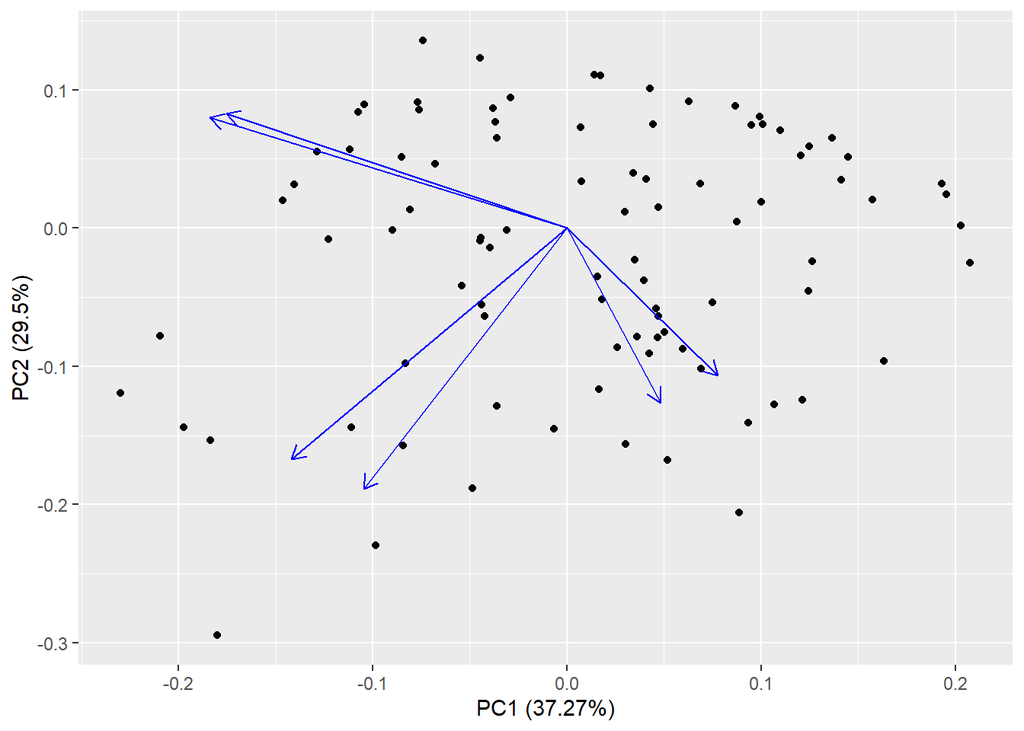

```r
## vector of pca loadings of interest
loadings <- c(1)
metrics <- c("rare.degree",
             "weighted.betweenness",
             "weighted.closeness",
             "niche.overlap",
             "species.strength",
             "d")

## the metrics used in the PCA
var.method <- cv
ave.method <- mean

#changed from pollinator to plant
plant.pca.scores <- calcPcaMeanVar(species.roles=species.roles,
                                   var.method=var.method,
                                   ave.method=ave.method,
                                   metrics= metrics,
                                   loadings=loadings,
                                   agg.col = "Year")

autoplot(plant.pca.scores$'2019'$pca.loadings, loadings=TRUE,
         loadings.colour = 'blue')
```

```r
plant.pca.scores.df <- do.call(rbind, lapply(plant.pca.scores, function(x) x$pcas))
```

### VII. Floral Abundance

I calculated floral abundance using the vegetation dataset (4detlaAbund.R). I first calculated floral abundance for each plant species in a site within a single year. I then calculated the difference in abundance between year pairs (e.g., 2019-2020, 2020-2021, etc.), and then the log-ratio of these values. The resulting dataset was the floral abundance dataset which had log-ratio values of the difference in abundance between year pairs.

```r
setwd('C:/pisgah-prairie/analysis')
source('src/setup.R')
source('src/delta.R')
source('src/misc.R')
load('../data/specimens/spec1.Rdata')
load('../data/veg/veg1.Rdata')

## Calculate the abundance of each species in each year
plant.abund <- calcPlantABund(spec)

## calculate the difference the log ratio of abundance between year pairs
plant.delta <- calcPlantYearDiff(plant.abund)
```

```
## [1] 2019
## [1] 2020
## [1] 2021
```

```r
#converts list to dataframe
plant.delta.df <- bind_rows(plant.delta , .id = "Year")

plant.delta.tidy <- plant.delta.df%>%
  rename(PlantGenusSpecies = GenusSpecies) %>%
  mutate(Site = as.character(Site),
         Year = as.character(Year),
         PlantGenusSpecies = as.character(PlantGenusSpecies))
```

### VIII. Join Datasets

I joined datasets that I needed to create my linear models (5joinData.R). The datasets of interest were beta-diversity, PCA scores, network roles, and floral abundance datasets. I standardized class type for year, site, plant genus species as character. I then created a key in each dataset to later join the datasets into a single data frame. The output data frame included beta-diversity values, PCA scores (mean and variance), network roles, and log-ratio floral abundances (for year pairs) for each plant species at a site within a single year.

```r
setwd('C:/pisgah-prairie/analysis/saved')
load('../saved/results/specRoles.Rdata')
load('../saved/results/deltaAbund.Rdata')
load('../saved/results/partnerVar.Rdata')
load('../saved/results/pcaVar.Rdata')

#Create key SpSiteYear and change class to character for each dataframe
delta.tidy <- plant.delta.tidy %>%
  dplyr::mutate(
    PlantGenusSpecies = as.character(PlantGenusSpecies),
    Year = as.character(Year),
    Site = as.character(Site),
    SpSiteYear = paste0(PlantGenusSpecies, Site, Year, " "),
    SpSiteYear = trimws(SpSiteYear))

beta.dist.tidy <- beta.dist %>%
  dplyr::mutate(
    PlantGenusSpecies = as.character(PlantGenusSpecies),
    Year = as.character(Year),
    Site = as.character(Site),
    SpSiteYear = paste0(PlantGenusSpecies, Site, Year, " "),
    SpSiteYear = trimws(SpSiteYear))

spec.roles.tidy <- species.roles %>%
  dplyr::rename(PlantGenusSpecies = GenusSpecies) %>%
  dplyr::mutate(
    PlantGenusSpecies = as.character(PlantGenusSpecies),
    Year = as.character(Year),
    Site = as.character(Site),
    SpSiteYear = paste0(PlantGenusSpecies, Site, Year, " "),
    SpSiteYear = trimws(SpSiteYear))

pca.scores.tidy <- plant.pca.scores.df %>%
  dplyr::rename(PlantGenusSpecies = GenusSpecies) %>%
  dplyr::mutate(
    PlantGenusSpecies = as.character(PlantGenusSpecies),
    Year = as.character(Year),
    Site = as.character(Site),
    SpSiteYear = paste0(PlantGenusSpecies, Site, Year, " "),
    SpSiteYear = trimws(SpSiteYear))

#Check structure of SpSiteYear for consistency
str(delta.tidy$SpSiteYear)
```

```
##  chr [1:321] "Camassia quamashFisher Butte2019" ...
```

```r
str(beta.dist.tidy$SpSiteYear)
```

```
##  chr [1:387] "Camassia quamashFisher Butte2019" ...
```

```r
str(spec.roles.tidy$SpSiteYear)
```

```
##  chr [1:407] "Erigeron decumbensAnkeny Wildlife Refuge2019" ...
```

```r
head(delta.tidy$SpSiteYear, n = 10)
```

```
##  [1] "Camassia quamashFisher Butte2019"
##  [2] "Cardamine pendulifloraFisher Butte2019"
##  [3] "Lomatium bradshawiiFisher Butte2019"
##  [4] "Ranunculus alismifoliusFisher Butte2019"
##  [5] "Ranunculus orthorhynchusFisher Butte2019"
##  [6] "Plagiobothrys figuratusFisher Butte2019"
##  [7] "Castilleja tenuisFisher Butte2019"
##  [8] "Eriophyllum lanatumFisher Butte2019"
##  [9] "Ranunculus occidentalisFisher Butte2019"
## [10] "Downingia yinaFisher Butte2019"
```

```r
head(beta.dist.tidy$SpSiteYear, n = 10)
```

```
##  [1] "Camassia quamashFisher Butte2019"
##  [2] "Camassia quamashFisher Butte2019"
##  [3] "Camassia quamashJefferson Farm2019"
##  [4] "Camassia quamashJefferson Farm2019"
##  [5] "Camassia quamashOxbow West2019"
##  [6] "Clarkia purpureaBald Hill2019"
##  [7] "Clarkia purpureaFinley Wildlife Refuge2019"
##  [8] "Clarkia purpureaJefferson Farm2019"
##  [9] "Crepis setosaBald Hill2019"
## [10] "Crepis setosaJefferson Farm2019"
```

```r
head(spec.roles.tidy$SpSiteYear, n = 10)
```

```
##  [1] "Erigeron decumbensAnkeny Wildlife Refuge2019"
##  [2] "Eriophyllum lanatumAnkeny Wildlife Refuge2019"
##  [3] "Potentilla gracilisAnkeny Wildlife Refuge2019"
##  [4] "Castilleja levisectaAnkeny Wildlife Refuge2021"
##  [5] "Heracleum maximumAnkeny Wildlife Refuge2021"
##  [6] "Potentilla gracilisAnkeny Wildlife Refuge2021"
##  [7] "Sidalcea asprellaAnkeny Wildlife Refuge2021"
##  [8] "Sidalcea campestrisAnkeny Wildlife Refuge2021"
##  [9] "Brassica rapaAnkeny Wildlife Refuge2021"
## [10] "Heracleum maximumAnkeny Wildlife Refuge2021"
```

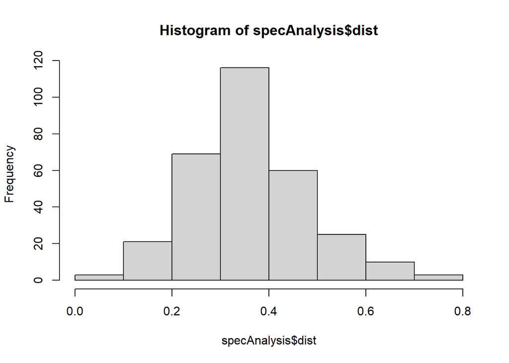

```r
#Join dataframes
specAnalysis <- spec.roles.tidy %>%
  dplyr::left_join(delta.tidy %>% select(-Year, -Site, -PlantGenusSpecies), by = "SpSiteYear") %>%
  dplyr::left_join(beta.dist.tidy %>% select(-Year, -Site, -Date, -PlantGenusSpecies), by = "SpSiteYear") %>%
  dplyr::left_join(pca.scores.tidy %>% select(-Year, -Site, -PlantGenusSpecies), by = "SpSiteYear")

# Filter data for non-zero deltaAbund and beta dispersion
specAnalysis <- specAnalysis %>%
  dplyr::filter(dist != 0, deltaAbund != 0, mean.pca1 !=0) %>%
  na.omit()

#visualize data of interest
hist(specAnalysis$dist)
```

```r
hist(specAnalysis$deltaAbund)
```

[output not shown]

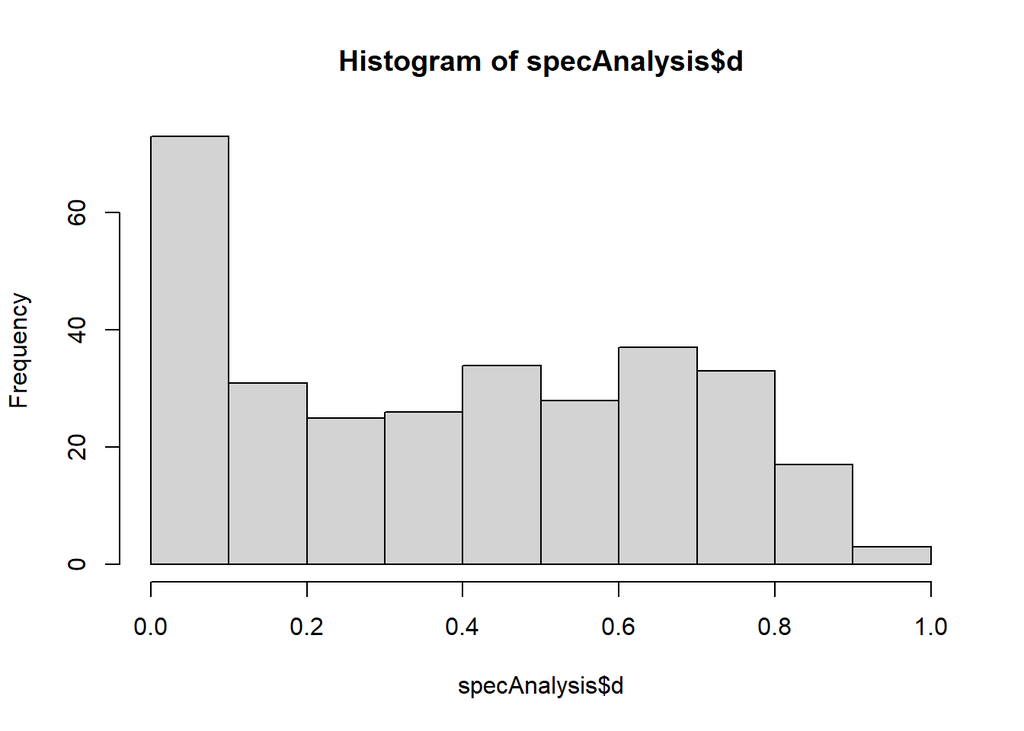

```r
hist(specAnalysis$d)
```

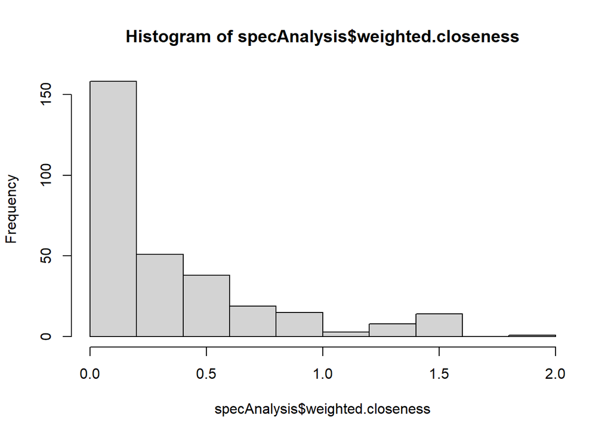

```r
hist(specAnalysis$weighted.closeness)
```

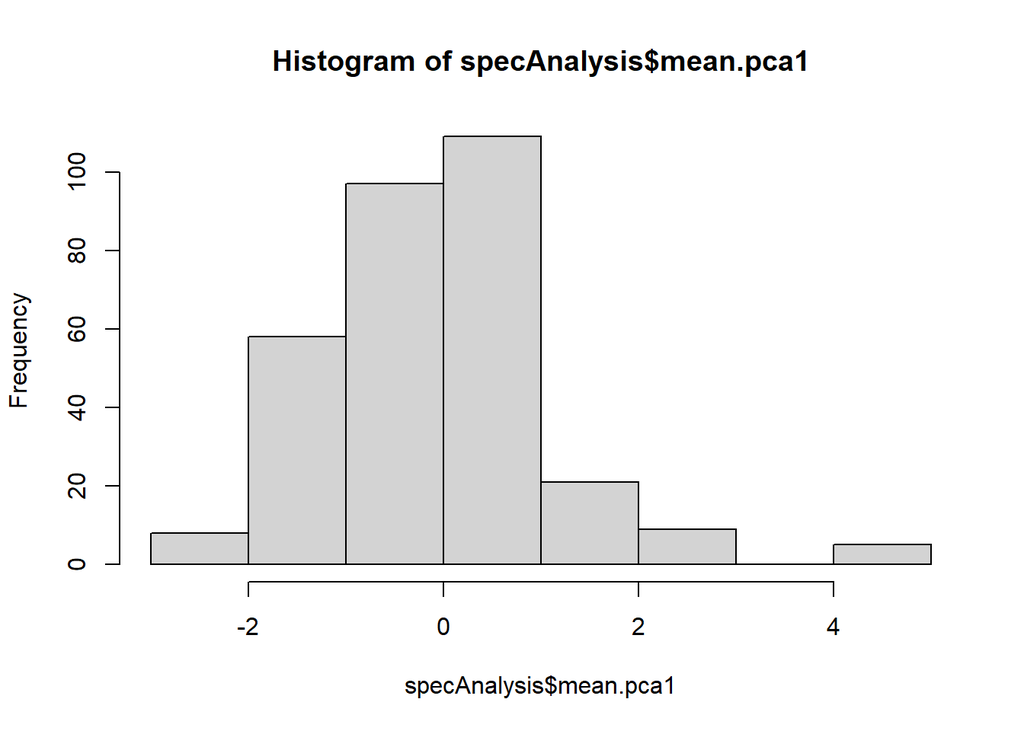

```r
hist(specAnalysis$mean.pca1)
```

### IX. Linear Models

```r
setwd('C:/pisgah-prairie/analysis')
load('saved/results/specAnalysis.Rdata')
source('src/predictIntervals.R')

## visualizes and removes outliers.
## The outliers have no effect on models and is more visually appealing when removed
hist(specAnalysis$deltaAbund)
```

[output not shown]

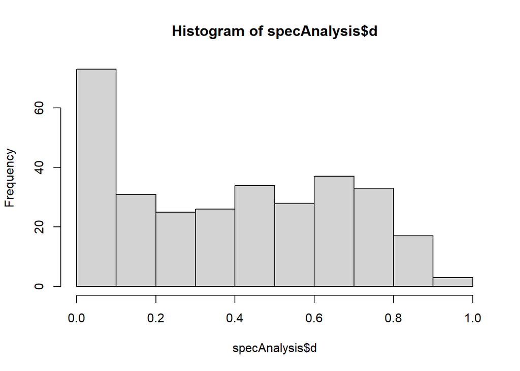

```r
hist(specAnalysis$d)
```

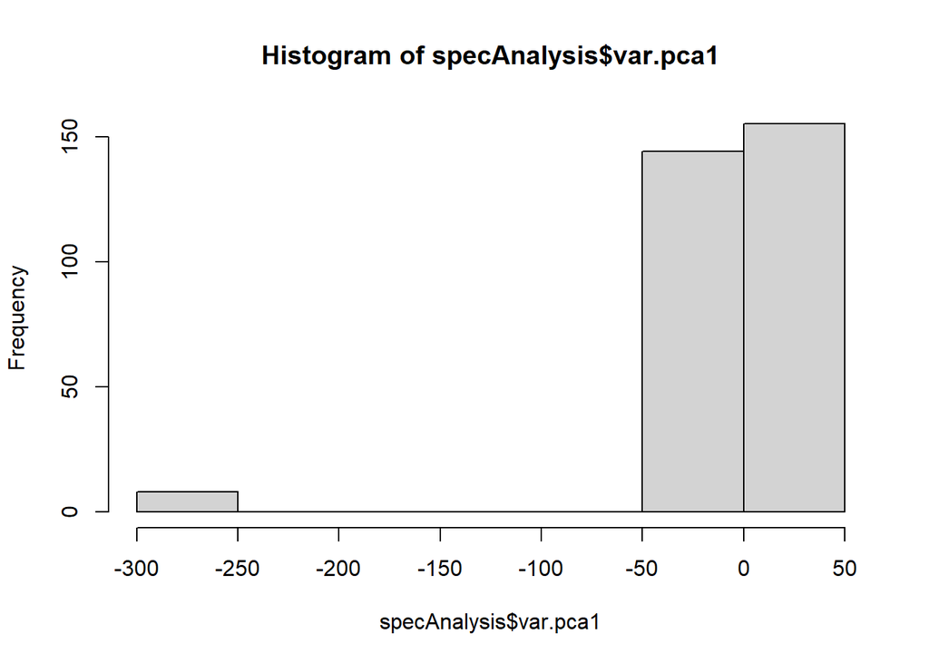

```r
hist(specAnalysis$var.pca1)
```

```r
hist(specAnalysis$deltaAbund)
```

[output not shown]

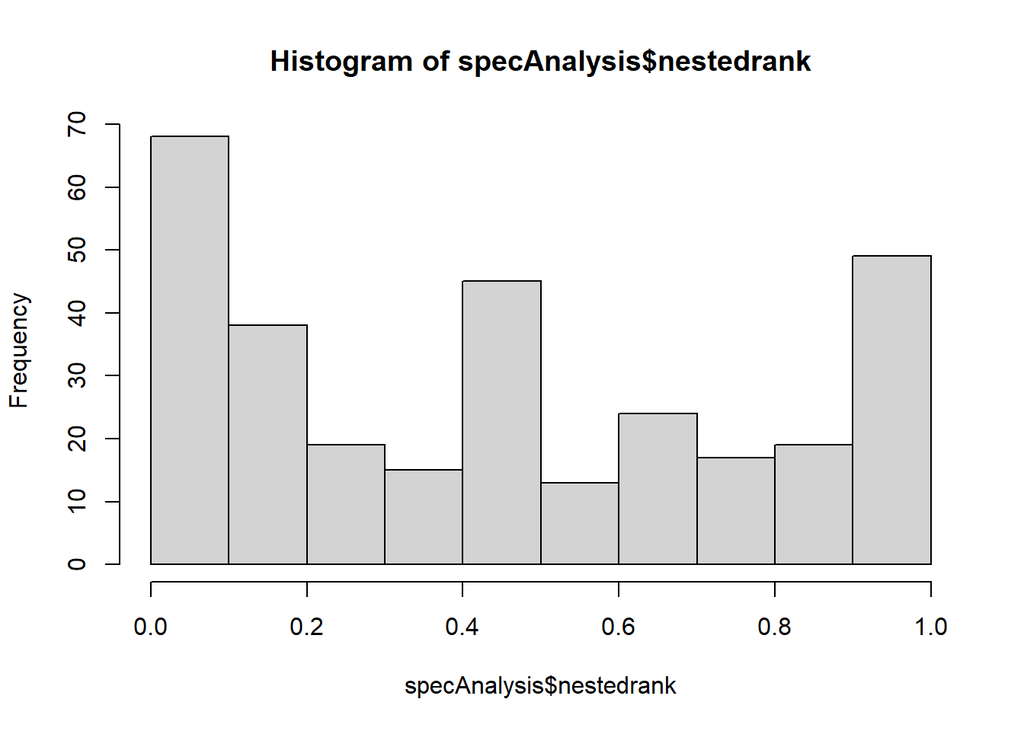

```r
hist(specAnalysis$nestedrank)
```

```r
sum(is.na(specAnalysis$deltaAbund))
```

```
## [1] 0
```

```r
#Create linear mixed models
##############
##Delta floral abundance vs partner variability
##############
delta.abund.mod <- lmerTest::lmer(deltaAbund ~ scale(dist) + (1|Site),  data = specAnalysis)
summary(delta.abund.mod)
```

```
## Linear mixed model fit by REML. t-tests use Satterthwaite's method [
## lmerModLmerTest]
## Formula: deltaAbund ~ scale(dist) + (1 | Site)
##    Data: specAnalysis
##
## REML criterion at convergence: 298.9
##
## Scaled residuals:
##     Min      1Q  Median      3Q     Max
## -1.2628 -0.5368 -0.2267  0.3867  9.0457
##
## Random effects:
##  Groups   Name        Variance Std.Dev.
##  Site     (Intercept) 0.01828  0.1352
##  Residual             0.14614  0.3823
## Number of obs: 307, groups:  Site, 7
##
## Fixed effects:
##              Estimate Std. Error        df t value Pr(>|t|)
## (Intercept)   0.63793    0.06239   5.17981  10.224 0.000125 ***
## scale(dist)  -0.02425    0.02207 302.07175  -1.099 0.272801
## ---
## Signif. codes:  0 '***' 0.001 '**' 0.01 '*' 0.05 '.' 0.1 ' ' 1
##
## Correlation of Fixed Effects:
##             (Intr)
## scale(dist) -0.007
```

```r
##############
##d vs partner variability
##############
d.mod <- lmerTest::lmer(d ~ scale(dist) + (1|Site), data = specAnalysis)
summary(d.mod)
```

```
## Linear mixed model fit by REML. t-tests use Satterthwaite's method [
## lmerModLmerTest]
## Formula: d ~ scale(dist) + (1 | Site)
##    Data: specAnalysis
##
## REML criterion at convergence: 106.1
##
## Scaled residuals:
##      Min       1Q   Median       3Q      Max
## -1.55460 -0.93354  0.06884  0.94351  1.86516
##
## Random effects:
##  Groups   Name        Variance Std.Dev.
##  Site     (Intercept) 0.00000  0.0000
##  Residual             0.07986  0.2826
## Number of obs: 307, groups:  Site, 7
##
## Fixed effects:
##              Estimate Std. Error        df t value Pr(>|t|)
## (Intercept)   0.38994    0.01613 305.00000  24.177   <2e-16 ***
## scale(dist)   0.01508    0.01615 305.00000   0.933    0.351
## ---
## Signif. codes:  0 '***' 0.001 '**' 0.01 '*' 0.05 '.' 0.1 ' ' 1
##
## Correlation of Fixed Effects:
##             (Intr)
## scale(dist) 0.000
## optimizer (nloptwrap) convergence code: 0 (OK)
## boundary (singular) fit: see help('isSingular')
```

```r
##############
##Weighted closeness vs partner variability
##############
close.mod <- lmerTest::lmer(weighted.closeness ~ scale(dist) + (1|Site), data = specAnalysis)
summary(close.mod)
```

```
## Linear mixed model fit by REML. t-tests use Satterthwaite's method [
## lmerModLmerTest]
## Formula: weighted.closeness ~ scale(dist) + (1 | Site)
##    Data: specAnalysis
##
## REML criterion at convergence: 338.6
##
## Scaled residuals:
##     Min      1Q  Median      3Q     Max
## -1.0336 -0.6729 -0.3955  0.3389  3.3785
##
## Random effects:
##  Groups   Name        Variance Std.Dev.
##  Site     (Intercept) 0.005241 0.0724
##  Residual             0.168936 0.4110
## Number of obs: 307, groups:  Site, 7
##
## Fixed effects:
##              Estimate Std. Error        df t value Pr(>|t|)
## (Intercept)   0.37222    0.04084   2.69532   9.114  0.00423 **
## scale(dist)   0.01945    0.02367 304.06757   0.822  0.41183
## ---
## Signif. codes:  0 '***' 0.001 '**' 0.01 '*' 0.05 '.' 0.1 ' ' 1
##
## Correlation of Fixed Effects:
##             (Intr)
## scale(dist) 0.001
```

```r
##############
##Nestedness vs partner variability
##############
nested.mod <- lmerTest::lmer(nestedrank ~ scale(dist) + (1|Site), data = specAnalysis)
summary(nested.mod)
```

```
## Linear mixed model fit by REML. t-tests use Satterthwaite's method [
## lmerModLmerTest]
## Formula: nestedrank ~ scale(dist) + (1 | Site)
##    Data: specAnalysis
##
## REML criterion at convergence: 239.9
##
## Scaled residuals:
##     Min      1Q  Median      3Q     Max
## -1.3684 -0.8668  0.1026  0.8237  1.6635
##
## Random effects:
##  Groups   Name        Variance Std.Dev.
##  Site     (Intercept) 0.000687 0.02621
##  Residual             0.123365 0.35123
## Number of obs: 307, groups:  Site, 7
##
## Fixed effects:
##               Estimate Std. Error         df t value Pr(>|t|)
## (Intercept)   0.452063   0.023668   1.405448  19.100   0.0114 *
## scale(dist)  -0.009943   0.020137 303.904820  -0.494   0.6218
## ---
## Signif. codes:  0 '***' 0.001 '**' 0.01 '*' 0.05 '.' 0.1 ' ' 1
##
## Correlation of Fixed Effects:
##             (Intr)
## scale(dist) 0.003
```

```r
##############
##role variability vs partner variability
##############
#identify extreme outliers and remove (-300+ variance)
which(specAnalysis$var.pca1 < -100)
```

```
## [1] 135 136 137 138 144 145 146 147
```

```r
specAnalysis <- specAnalysis[-c(135, 136, 137, 138, 144, 145, 146, 147), ]
pca.mod <- lmerTest::lmer(var.pca1 ~ scale(dist) + (1|Site), data = specAnalysis)
summary(pca.mod)
```

```
## Linear mixed model fit by REML. t-tests use Satterthwaite's method [
## lmerModLmerTest]
## Formula: var.pca1 ~ scale(dist) + (1 | Site)
##    Data: specAnalysis
##
## REML criterion at convergence: 2135.7
##
## Scaled residuals:
##     Min      1Q  Median      3Q     Max
## -3.9612 -0.2513  0.1900  0.4358  2.9495
##
## Random effects:
##  Groups   Name        Variance Std.Dev.
##  Site     (Intercept)  3.006   1.734
##  Residual             73.616   8.580
## Number of obs: 299, groups:  Site, 7
##
## Fixed effects:
##             Estimate Std. Error       df t value Pr(>|t|)
## (Intercept)  -1.0764     0.9353   3.3188  -1.151   0.3259
## scale(dist)   1.2290     0.5009 295.6160   2.453   0.0147 *
## ---
## Signif. codes:  0 '***' 0.001 '**' 0.01 '*' 0.05 '.' 0.1 ' ' 1
##
## Correlation of Fixed Effects:
##             (Intr)
## scale(dist) 0.000
```

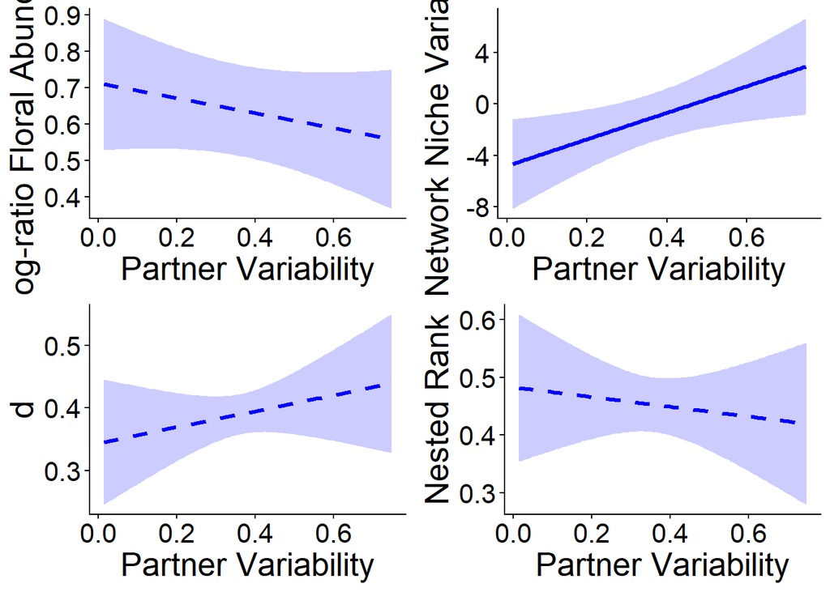

```r
#This function uses a linear model to predict values for a network metric
#and creates plots to visualize
plot.s <- function(specAnalysis, response, mod) {
  # Create prediction grid
  expand.grid <- data.frame(
    dist = seq(min(specAnalysis$dist),
               max(specAnalysis$dist),
               length.out = 100)
  )

  # Add placeholder column for response
  expand.grid[[response]] <- 0

  # Predict using custom function
  pred <- predict.int(mod = mod,
                      dd = expand.grid,
                      y = response,
                      family = "gaussian")

  # Plot
  ggplot() +
    # geom_point(data = pred, aes(x = dist, y = .data[[response]])) +
    geom_line(data = pred, aes(x = dist, y = .data[[response]]), color = "blue", linewidth = 1.2) +
    geom_ribbon(data = pred, aes(x = dist, ymin = plo, ymax = phi), alpha = 0.2, fill = "blue") +
    theme_classic() +
    theme(text = element_text(size = 20))
}

plot.ns <- function(specAnalysis, response, mod) {
  # Create prediction grid
  expand.grid <- data.frame(
    dist = seq(min(specAnalysis$dist),
               max(specAnalysis$dist),
               length.out = 100)
  )

  # Add placeholder column for response
  expand.grid[[response]] <- 0

  # Predict using custom function
  pred <- predict.int(mod = mod,
                      dd = expand.grid,
                      y = response,
                      family = "gaussian")

  # Plot
  ggplot() +
    # geom_point(data = pred, aes(x = dist, y = .data[[response]])) +
    geom_line(data = pred, aes(x = dist, y = .data[[response]]), color = "blue", linetype = "dashed", linewidth = 1.2) +
    geom_ribbon(data = pred, aes(x = dist, ymin = plo, ymax = phi), alpha = 0.2, fill = "blue") +
    theme_classic() +
    theme(text = element_text(size = 20))
}

##Plot models
#########################
##Delta abundance vs partner variability
#########################
delta.abund.plot <- plot.ns(specAnalysis, "deltaAbund", delta.abund.mod)

delta.abund.plot.labeled <- delta.abund.plot + labs(x = "Partner Variability", y = "Log-ratio Floral Abundance")

#########################
##d vs partner variability
#########################
d.dist.plot <- plot.ns(specAnalysis, "d", d.mod)

d.dist.plot.labeled <- d.dist.plot + labs(x = "Partner Variability", y = "d")

#########################
##Nestedness vs partner variability
#########################
nested.dist.plot <- plot.ns(specAnalysis, "nestedrank", nested.mod)

nested.dist.plot.labeled <- nested.dist.plot + labs(x = "Partner Variability", y = "Nested Rank")

#########################
##Role variability vs partner variability
#########################
pca.dist.plot <- plot.s(specAnalysis, "var.pca1", pca.mod)

pca.dist.plot.labeled <- pca.dist.plot + labs(x = "Partner Variability", y = "Network Niche Variability")

#Combine plots into single grid
combinedPlot <- cowplot::plot_grid(delta.abund.plot.labeled, pca.dist.plot.labeled, d.dist.plot.labeled,
                                   nested.dist.plot.labeled, ncol = 2)
print(combinedPlot)
```

### X. Conclusions

Interestingly, partner variability was negatively associated with differences in floral abundance across pairwise years, although this relationship was not statistically significant. Floral abundance is linked to network asymmetry: abundant species tend to exert stronger interaction effects on their partners than they receive in return, whereas the opposite pattern is observed for rare species (Vázquez et al. 2007). In addition, the likelihood that a pollinator interacts with a particular plant is influenced by variation in floral abundance (Carstensen et al. 2014). In our case, from the plant’s perspective, changes in pairwise interactions did not affect floral abundance.

Aarssen, Lonnie W. 1989. “Competitive Ability and Species Coexistence: A ‘Plant’s‑eye’ View.” *Oikos* 56: 386–401.

Aarssen, LW. 1992. “Causes and Consequences of Variation in Competitive Ability in Plant Communities.” *Journal of Vegetation Science* 3 (2): 165–74.

Alarcón, Ruben, Nickolas M Waser, and Jeff Ollerton. 2008. “Year-to-Year Variation in the Topology of a Plant–Pollinator Interaction Network.” *Oikos* 117 (12): 1796–1807.

Altman, Bob. 2011. “Historical and Current Distribution and Populations of Bird Species in Prairie-Oak Habitats in the Pacific Northwest.” *Northwest Science* 85 (2): 194–222.

Bengtsson, Jan, Torbjörn Fagerström, and Håkan Rydin. 1994. “Competition and Coexistence in Plant Communities.” *Trends in Ecology & Evolution* 9 (7): 246–50.

Bergamo, Pedro Joaquim, Anna Traveset, and Amparo Lázaro. 2021. “Pollinator-Mediated Indirect Effects on Plant Fecundity Revealed by Network Indices.” *The American Naturalist* 198 (6): 734–49. https://doi.org/10.1086/716896.

Carstensen, Daniel W, Malena Sabatino, Kristian Trøjelsgaard, and Leonor Patricia C Morellato. 2014. “Beta Diversity of Plant-Pollinator Networks and the Spatial Turnover of Pairwise Interactions.” *PLoS One* 9 (11): e112903.

Cosmo, Leandro G, Ana Paula A Assis, Marcus AM de Aguiar, Mathias M Pires, Alfredo Valido, Pedro Jordano, John N Thompson, Jordi Bascompte, and Paulo R Guimaraes Jr. 2023. “Indirect Effects Shape Species Fitness in Coevolved Mutualistic Networks.” *Nature* 619 (7971): 788–92.

Gaiarsa, Marı́lia Palumbo, Claire Kremen, and Lauren C Ponisio. 2021. “Pollinator Interaction Flexibility Across Scales Affects Patch Colonization and Occupancy.” *Nature Ecology & Evolution* 5 (6): 787–93.

Gómez, José M, Francisco Perfectti, and Pedro Jordano. 2011. “The Functional Consequences of Mutualistic Network Architecture.” *PLoS One* 6 (1): e16143.

González, Alejandra V, Maureen M Murúa, and Fernanda Pérez. 2015. “Floral Integration and Pollinator Diversity in the Generalized Plant-Pollinator System of Alstroemeria Ligtu (Alstroemeriaceae).” *Evolutionary Ecology* 29 (1): 63–75.

Herrera, Carlos M. 2005. “Plant Generalization on Pollinators: Species Property or Local Phenomenon?” *American Journal of Botany* 92 (1): 13–20. https://doi.org/10.3732/ajb.92.1.13.

Olesen, Jens M, Jordi Bascompte, Heidi Elberling, and Pedro Jordano. 2008. “Temporal Dynamics in a Pollination Network.” *Ecology* 89 (6): 1573–82.

Ponisio, Lauren C. 2020. “Pyrodiversity Promotes Interaction Complementarity and Population Resistance.” *Ecology and Evolution* 10 (10): 4431–47.

Sinclair, Marcia, E Alverson, Patrick Dunn, Peter Dunwiddie, and E Gray. 2006. “Bunchgrass Prairies.” *Restoring the Pacific Northwest: The Art and Science of Ecological Restoration in Cascadia*, 29–62.

Valdovinos, Fernanda S., Berry J. Brosi, Heather M. Briggs, Pablo Moisset De Espanés, Rodrigo Ramos‐Jiliberto, and Neo D. Martinez. 2016. “Niche Partitioning Due to Adaptive Foraging Reverses Effects of Nestedness and Connectance on Pollination Network Stability.” Edited by Jonathan Chase. *Ecology Letters* 19 (10): 1277–86. https://doi.org/10.1111/ele.12664.

Van Der Kooi, Casper J, Mario Vallejo-Marı́n, and Sara D Leonhardt. 2021. “Mutualisms and (a) Symmetry in Plant–Pollinator Interactions.” *Current Biology* 31 (2): R91–99.

Vázquez, Diego P, Carlos J Melián, Neal M Williams, Nico Blüthgen, Boris R Krasnov, and Robert Poulin. 2007. “Species Abundance and Asymmetric Interaction Strength in Ecological Networks.” *Oikos* 116 (7): 1120–27.

Waser, Nickolas M. 2006. “Specialization and Generalization in Plant-Pollinator Interactions: A Historical Perspective.” In *Plant-Pollinator Interactions: From Specialization to Generalization*, edited by Nickolas M. Waser and Jeff Ollerton, 3–17. Chicago: University of Chicago Press.